# Interval Truth Model

- Show All Code
- Hide All Code
- View Source

Visualizations of Main Simulation Study

Authors

Affiliation

Matthias Kloft

University of Marburg

Björn S. Siepe

University of Marburg

Daniel W. Heck

University of Marburg

Published

July 22, 2025

# 1 Background

This file contains the visualizations of the simulation study for the Interval Truth Model. The results of the preliminary simulation study on the two different link functions can be found in the file `src/05_sim_link_functions_visualizations.Qmd`.

All errorbars in this document represent $\pm 1$ Monte Carlo Standard Errors.

# 2 Prep

We first load all relevant packages:

```r
packages <- c(
  "tidyverse",
  "SimDesign",
  "here",
  "psych",
  "ggh4x",
  "ggokabeito",
  "ggExtra",
  "showtext",
  "ggdist",
  "pander",
  "sysfonts"
)

if (!require("pacman")) install.packages("pacman")
pacman::p_load(packages, update = F, character.only = T)

if(!require("cmdstanr")){
  install.packages("cmdstanr", repos = c("https://mc-stan.org/r-packages/", getOption("repos")))
  library(cmdstanr)
}


# default chunk options
knitr::opts_chunk$set(
  fig.height = 7,
  fig.width = 10,
  include = TRUE,
  message = FALSE,
  warning = FALSE
)
source(here("src", "00_functions.R"))

# add google font
sysfonts::font_add_google("News Cycle", "news")
# use showtext
showtext::showtext_auto()
```

As the true locations and width have slightly different standard deviations, we can use these to standardize performance meausures for ease of interpretability. Obtain the SDs from the data-generation function:

```r
link <- "ilr"
mean_benchmark <- simplex_to_bvn(c(.4, .2, .4), type = link)
sd_benchmark_loc <- simplex_to_bvn(c(.98, .01, .01), type = link)
sd_benchmark_wid <- simplex_to_bvn(c(.495, .01, .495), type = link)

# mean for Tr_loc
mu_Tr_loc <- mean_benchmark[1]

# mean for Tr_wid
mu_Tr_wid <- mean_benchmark[2]

# SD forTr_loc
sigma_Tr_loc <- sd_benchmark_loc[1] / 4

# SD Tr_wid
sigma_Tr_wid <- abs(sd_benchmark_wid[2] - mean_benchmark[2]) / 4
```

# 3 Results

The full results of the simulation study are available in two data frames:

- `sim_res_itm_server.rds`: Results of the simulation study, missing some MSE results due to a small coding error, but containing all information about seed, RAM usage, etc.
- `sim_res_itm_0808.rds`: Resummarized results of the simulation study, now also containing all MSE results as well as more information on divergent transitions.

```r
sim_res_itm <- readRDS(
  here(
    "sim_results",
    "sim_results_itm_2024-09-07_07-27-33",
    "resummarized_results_itm.rds"
  )
)
```

Prepare data and convert to long format for plotting:

```r
sim_res_itm_long <- sim_res_itm |>
  select(!c(contains("conv"), contains("divtrans"), contains("_sd"))) |>
  # the following columns aren't needed any more for the "resummarized" results
            # "REPLICATIONS", "SIM_TIME", "RAM_USED", "SEED", "COMPLETED", "WARNINGS")) |>
  # delete "_fn_" from every column name
  rename_all(~str_remove(., "_fn")) |>
  pivot_longer(cols = !c(n_respondents, n_items),
               names_to = "measure",
               values_to = "value") |>
  # rename for easier separation
  mutate(measure = str_replace(measure, "abs_bias", "absbias")) |>
  # add string so that each measure has same number of underscores
  mutate(measure = str_replace(measure, "omega", "omega_cor")) |>
  # remove only the first underscore
  mutate(measure = sub("_", "", measure, fixed = TRUE)) |>
  separate_wider_delim(measure,
                       names = c("measure", "summary", "pm", "param"),
                       delim = "_") |>
  group_by(n_respondents, n_items, measure, summary, pm) |>
  pivot_wider(names_from = "param", values_from = "value") |>
  ungroup() |>
  mutate(n_respondents = factor(n_respondents))
```

## 3.1 Convergence and Rhat

We now present the average convergence statistics. All values are averages over all replications. A performance measure with a $>$ or a $<$ indicates how many out of 1000 replications had a certain property. For example, $\hat{R} < 1.1$ means that on average, a certain amount of replications had an $\hat{R}$ value below 1.1.

```r
# Renaming for the table
name_mapping <- c(
  "rhat_mean" = "$\\hat{R}_{\\text{mean}}$",
  "rhat_prop1c1" = "$\\hat{R} < 1.1$",
  "rhat_prop1c05" = "$\\hat{R} < 1.05$",
  "rhat_prop1c01" = "$\\hat{R} < 1.01$",
  "ess_bulk_mean" = "$\\text{ESS}_{\\text{bulk, mean}}$",
  "ess_bulk_prop100" = "$\\text{ESS}_{\\text{bulk > 100}}$",
  "ess_bulk_prop200" = "$\\text{ESS}_{\\text{bulk > 200}}$",
  "ess_bulk_prop300" = "$\\text{ESS}_{\\text{bulk > 300}}$",
  "ess_bulk_prop400" = "$\\text{ESS}_{\\text{bulk > 400}}$",
  "ess_tail_mean" = "$\\text{ESS}_{\\text{tail, mean}}$",
  "ess_tail_prop100" = "$\\text{ESS}_{\\text{tail > 100}}$",
  "ess_tail_prop200" = "$\\text{ESS}_{\\text{tail > 200}}$",
  "ess_tail_prop300" = "$\\text{ESS}_{\\text{tail > 300}}$",
  "ess_tail_prop400" = "$\\text{ESS}_{\\text{tail > 400}}$"
)

sim_res_itm |>
  dplyr::select(contains("conv")) |>
  summarize(across(everything(), mean)) |>
  # remove "mean_conv." from every column name
  rename_all(~str_remove(., "mean_conv.")) |>
  rename_all(~str_remove(., "mcse_conv.")) |>
  pivot_longer(cols = everything()) |>
  # separate mean and mcse based on last underscore
  separate(name, into = c("name", "suffix"), sep = "_(?=[^_]+$)", remove = FALSE) |>
  pivot_wider(names_from = suffix, values_from = value) |>
  mutate(mean = round(mean, 4),
         mcse = round(mcse, 4)) |>
  mutate(name = name_mapping[name]) |>
  knitr::kable()
```

| name | mean | mcse |
| --- | --- | --- |
| $\hat{R}_{\text{mean}}$ | 1.0022 | 0.0000 |
| $\hat{R} < 1.1$ | 1.0000 | 0.0000 |
| $\hat{R} < 1.05$ | 1.0000 | 0.0001 |
| $\hat{R} < 1.01$ | 0.9896 | 0.0042 |
| $\text{ESS}_{\text{bulk, mean}}$ | 1894.3809 | 12.2391 |
| $\text{ESS}_{\text{bulk > 100}}$ | 1.0000 | 0.0001 |
| $\text{ESS}_{\text{bulk > 200}}$ | 0.9998 | 0.0005 |
| $\text{ESS}_{\text{bulk > 300}}$ | 0.9985 | 0.0013 |
| $\text{ESS}_{\text{bulk > 400}}$ | 0.9942 | 0.0027 |
| $\text{ESS}_{\text{tail, mean}}$ | 1425.3339 | 2.4341 |
| $\text{ESS}_{\text{tail > 100}}$ | 1.0000 | 0.0001 |
| $\text{ESS}_{\text{tail > 200}}$ | 1.0000 | 0.0002 |
| $\text{ESS}_{\text{tail > 300}}$ | 0.9999 | 0.0004 |
| $\text{ESS}_{\text{tail > 400}}$ | 0.9997 | 0.0006 |

The divergent transitions are shown in the table below. For purposes of readability, we omit the MCSEs here.

```r
sim_res_itm |>
  dplyr::select(contains("divtrans")) |>
  dplyr::select(-contains("mcse")) |>
  rename(
    "Mean DivTrans (all)" = "mean_divtrans.divergent_transitions_mean",
    "Proportion with DivTrans" = "nonz_divtrans.divergent_transitions_nonzero",
    "Mean DivTrans (models with any DivTrans)" = "nonzmean_divtrans.divergent_transitionsnonzero_mean"
  ) |>
  round(3) |>
  knitr::kable()
```

| Mean DivTrans (all) | Proportion with DivTrans | Mean DivTrans (models with any DivTrans) |
| --- | --- | --- |
| 0.32 | 0.012 | 26.667 |
| 0.00 | 0.000 | NaN |
| 0.00 | 0.000 | NaN |
| 0.00 | 0.000 | NaN |
| 0.00 | 0.000 | NaN |
| 0.00 | 0.000 | NaN |
| 0.00 | 0.000 | NaN |
| 0.00 | 0.000 | NaN |
| 0.00 | 0.000 | NaN |
| 0.00 | 0.000 | NaN |
| 0.00 | 0.000 | NaN |
| 0.04 | 0.002 | 20.000 |
| 0.00 | 0.000 | NaN |
| 0.00 | 0.000 | NaN |
| 0.00 | 0.000 | NaN |
| 0.04 | 0.002 | 20.000 |

Check if our prespecified MCSE criteria ($<.05$) was fulfilled in all conditions:

```r
sim_res_itm |>
  dplyr::select(all_of(contains("mcse"))) |>
  dplyr::select(all_of(contains("bias"))) |>
  summarize(across(everything(), max)) |>
  pivot_longer(cols = everything()) |>
  knitr::kable()
```

| name | value |
| --- | --- |
| a_loc_mean_fn_abs_bias_mcse | 0.0028364 |
| a_loc_median_fn_abs_bias_mcse | 0.0029909 |
| b_loc_mean_fn_abs_bias_mcse | 0.0022247 |
| b_loc_median_fn_abs_bias_mcse | 0.0021869 |
| b_wid_mean_fn_abs_bias_mcse | 0.0018055 |
| b_wid_median_fn_abs_bias_mcse | 0.0017596 |
| E_loc_mean_fn_abs_bias_mcse | 0.0090182 |
| E_loc_median_fn_abs_bias_mcse | 0.0060915 |
| E_wid_mean_fn_abs_bias_mcse | 0.0098181 |
| E_wid_median_fn_abs_bias_mcse | 0.0070934 |
| lambda_loc_mean_fn_abs_bias_mcse | 0.0040842 |
| lambda_loc_median_fn_abs_bias_mcse | 0.0036714 |
| lambda_wid_mean_fn_abs_bias_mcse | 0.0039844 |
| lambda_wid_median_fn_abs_bias_mcse | 0.0035551 |
| omega_mean_fn_abs_bias_mcse | 0.0037006 |
| omega_median_fn_abs_bias_mcse | 0.0036780 |
| simplemean_interval_mean_fn_abs_bias_mcse | 0.0062503 |
| simplemean_loc_mean_fn_abs_bias_mcse | 0.0049676 |
| simplemean_wid_mean_fn_abs_bias_mcse | 0.0036057 |
| Tr_interval_mean_fn_abs_bias_mcse | 0.0054971 |
| Tr_interval_median_fn_abs_bias_mcse | 0.0051850 |
| Tr_loc_mean_fn_abs_bias_mcse | 0.0041037 |
| Tr_loc_median_fn_abs_bias_mcse | 0.0037968 |
| Tr_wid_mean_fn_abs_bias_mcse | 0.0030948 |
| Tr_wid_median_fn_abs_bias_mcse | 0.0030753 |

## 3.2 Visualization

### 3.2.1 Absolute Bias of True Location + Width

#### 3.2.1.1 Combined AbsBias

Here, we show the absolute bias of the true location and width for the different sample sizes and number of items.

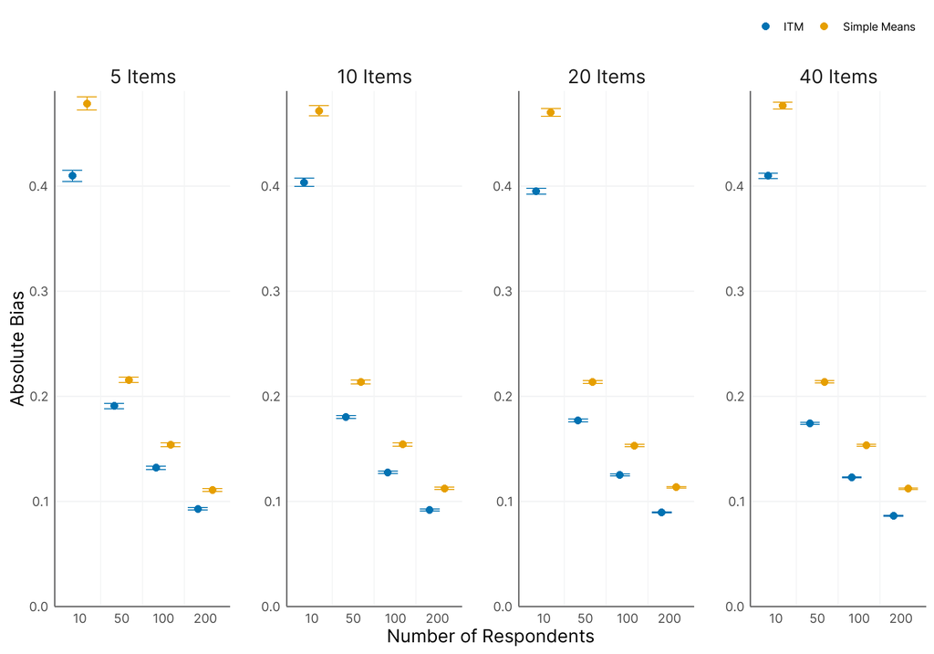

```r
plot_sim_absbias <- sim_res_itm_long |>
  filter(pm == "absbias") |>
  filter(summary == "mean") |>
  filter(measure %in% c("Trinterval", "simplemeaninterval")) |>
  mutate(measure = case_when(
    measure == "Trinterval" ~ "ITM",
    measure == "simplemeaninterval" ~ "Simple Means"
  )) |>
  mutate(n_items = paste0(n_items, " Items")) |>
  # order n_items correctly
  mutate(n_items = factor(n_items, levels = c("5 Items",
                                              "10 Items",
                                              "20 Items",
                                              "40 Items"))) |>
  ggplot(aes(x = n_respondents,
             y = mean,
             color = measure,
             group = measure)) +
  # add vertical line between different sample sizes
  geom_vline(colour = "#F3F4F5", xintercept = seq(1.5, 4, 1))+
  geom_point(position = position_dodge(0.7),
             size = 2.5) +
  geom_errorbar(aes(ymin = mean - 1*mcse,
                            ymax = mean + 1*mcse),
                        width = 0.95,
                 position = position_dodge(0.7),
                 show.legend = FALSE)+
  ggh4x::facet_wrap2(n_items ~ .,
                     axes = "all",
                     nrow = 1) +
  scale_y_continuous(limits = c(0, .49), expand = c(0,0)) +
  ggokabeito::scale_color_okabe_ito(order = c(5, 1))+
  labs(x = "Number of Respondents",
       y = "Absolute Bias",
       color = "") +
  theme_icm()+
  theme(legend.position = "top",
        text = element_text(size= 22))
  # For manuscript plot:
  # theme(legend.position = "top",
  #       text = element_text(size = 14),
  #       axis.text.x = element_text(size = 13, margin = margin(b = 10)),
  #       axis.text.y = element_text(size = 13, margin = margin(l = 10)),
  #       legend.text = element_text(size = 15.5))

# ggsave(here("plots","sim_main", "sim_absbias.pdf"),
#        plot_sim_absbias, width = 9, height = 4.5)

plot_sim_absbias
```

#### 3.2.1.2 Separate AbsBias

Here, we focus on the ITM and separate the bias by location and width.

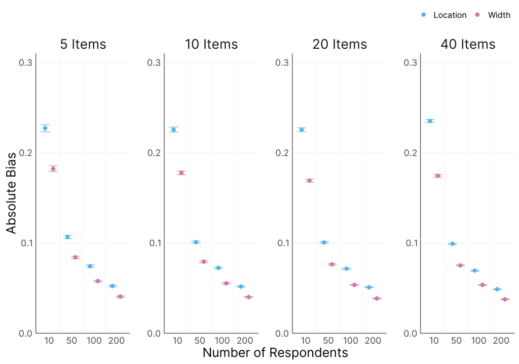

```r
plot_sim_bias_widloc <- sim_res_itm_long |>
  filter(pm == "absbias") |>
  filter(summary == "mean") |>
  filter(measure %in% c("Trloc", "Trwid")) |>
  mutate(measure = case_when(
    measure == "Trloc" ~ "Location",
    measure == "Trwid" ~ "Width"
  )) |>
  mutate(n_items = paste0(n_items, " Items")) |>
  # order n_items correctly
  mutate(n_items = factor(n_items, levels = c("5 Items",
                                              "10 Items",
                                              "20 Items",
                                              "40 Items"))) |>
  # # Standardize with true variability
  # mutate(mean = if_else(measure == "Location",
  #                       mean / sigma_Tr_loc,
  #                       mean / sigma_Tr_wid
  #                       ),
  #        mcse = if_else(measure == "Location",
  #                       mcse / sigma_Tr_loc,
  #                       mcse / sigma_Tr_wid
  #                       )) |>
  ggplot(aes(x = n_respondents,
             y = mean,
             color = measure,
             group = measure)) +
  # add vertical line between different sample sizes
  geom_vline(colour = "#F3F4F5", xintercept = seq(1.5, 4, 1))+
  geom_point(position = position_dodge(0.7),
             size = 2.5) +
  geom_errorbar(aes(ymin = mean - 1*mcse,
                            ymax = mean + 1*mcse),
                        width = .8,
                 position = position_dodge(0.7),
                 show.legend = FALSE)+
  ggh4x::facet_wrap2(n_items ~ .,
                     axes = "all",
                     nrow = 1) +
  scale_y_continuous(limits = c(0, 0.31), expand = c(0,0)) +
  ggokabeito::scale_color_okabe_ito(order = c(2, 7))+
  labs(x = "Number of Respondents",
       y = "Absolute Bias",
       color = "") +
  theme_icm()+
  theme(legend.position = "top",
        text = element_text(size = 28))

# ggsave(here("plots","sim_main", "sim_absbias_widloc.pdf"),
#        plot_sim_bias_widloc, width = 7, height = 3.75)

plot_sim_bias_widloc
```

Alternatively, combine plots for location and width:

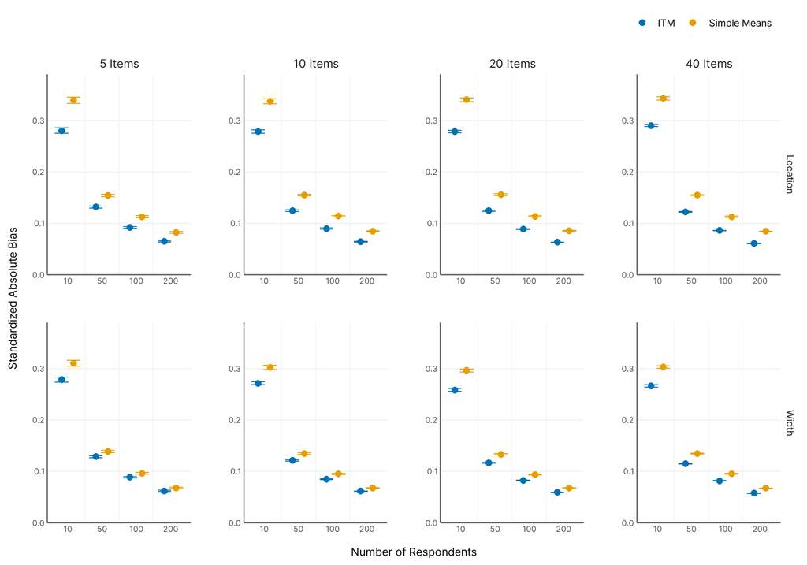

```r
plot_sim_absbias_widloc_comb <- sim_res_itm_long |>
  filter(pm == "absbias") |>
  filter(summary == "mean") |>
  filter(measure %in% c("Trloc", "Trwid", "simplemeanloc", "simplemeanwid")) |>
  # split based on model
  mutate(model = case_when(
    grepl("^Tr", measure) ~ "ITM",
    grepl("^simplemean", measure) ~ "Simple Means"
  ),
  measure = sub("^Tr|simplemean", "", measure)) |>
  mutate(measure = case_when(
    measure == "loc" ~ "Location",
    measure == "wid" ~ "Width")) |>
  # Standardize with true variability
  mutate(mean = if_else(measure == "Location",
                        mean / sigma_Tr_loc,
                        mean / sigma_Tr_wid
                        ),
         mcse = if_else(measure == "Location",
                        mcse / sigma_Tr_loc,
                        mcse / sigma_Tr_wid
                        )) |>
  mutate(n_items = paste0(n_items, " Items")) |>
  # order n_items correctly
  mutate(n_items = factor(n_items,
                          levels = c("5 Items", "10 Items", "20 Items", "40 Items"))) |>
  ggplot(aes(
    x = n_respondents,
    y = mean,
    color = model,
    group = model
  )) +
  # add vertical line between different sample sizes
  geom_vline(colour = "#F3F4F5", xintercept = seq(1.5, 4, 1)) +
  geom_point(position = position_dodge(0.7), size = 2.5) +
  geom_errorbar(
    aes(ymin = mean - 1 * mcse, ymax = mean + 1 * mcse),
    width = .8,
    position = position_dodge(0.7),
    show.legend = FALSE
  ) +
  ggh4x::facet_grid2(measure ~ n_items,
                     axes = "all") +
  scale_y_continuous(limits = c(0, 0.39), expand = c(0, 0)) +
  ggokabeito::scale_color_okabe_ito(order = c(5, 1)) +
  labs(x = "Number of Respondents", y = "Standardized Absolute Bias", color = "") +
  theme_icm() +
  # theme(legend.position = "top", text = element_text(size = 14))+
  # For manuscript plot:
  theme(legend.position = "top",
        text = element_text(size = 15.5),
        axis.text.x = element_text(size = 14., margin = margin(b = 10)),
        axis.text.y = element_text(size = 14.5, margin = margin(l = 10)),
        legend.text = element_text(size = 17.5))

plot_sim_absbias_widloc_comb
```

```r
ggsave(here("plots","sim_main", "sim_absbias_widloc_comb.pdf"),
       plot_sim_absbias_widloc_comb, width = 11, height = 7)
```

### 3.2.2 MSE for Location and Width

#### 3.2.2.1 Combined MSE

Show both ITM and simple means in a comparison:

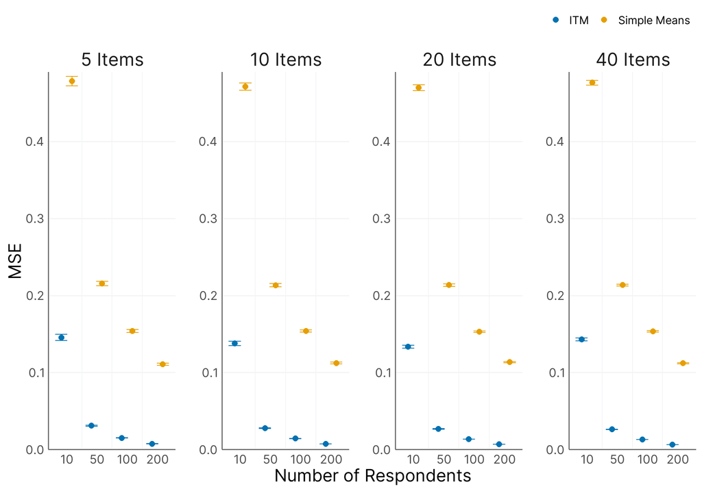

```r
plot_sim_mse <- sim_res_itm_long |>
  filter(pm == "mse") |>
  filter(summary == "mean") |>
  filter(measure %in% c("Trinterval", "simplemeaninterval")) |>
  mutate(measure = case_when(
    measure == "Trinterval" ~ "ITM",
    measure == "simplemeaninterval" ~ "Simple Means"
  )) |>
  mutate(n_items = paste0(n_items, " Items")) |>
  # order n_items correctly
  mutate(n_items = factor(n_items, levels = c("5 Items",
                                              "10 Items",
                                              "20 Items",
                                              "40 Items"))) |>
  ggplot(aes(x = n_respondents,
             y = mean,
             color = measure,
             group = measure)) +
  # add vertical line between different sample sizes
  geom_vline(colour = "#F3F4F5", xintercept = seq(1.5, 4, 1))+
  geom_point(position = position_dodge(0.7),
             size = 2.5) +
  geom_errorbar(aes(ymin = mean - 1*mcse,
                            ymax = mean + 1*mcse),
                        width = .8,
                 position = position_dodge(0.7),
                 show.legend = FALSE)+
  ggh4x::facet_wrap2(n_items ~ .,
                     axes = "all",
                     nrow = 1) +
  scale_y_continuous(limits = c(0, .49), expand = c(0,0)) +
  ggokabeito::scale_color_okabe_ito(order = c(5, 1))+
  labs(x = "Number of Respondents",
       y = "MSE",
       color = "") +
  theme_icm()+
  theme(legend.position = "top",
        text = element_text(size = 28))

# ggsave(here("plots","sim_main", "sim_mse.pdf"),
#        plot_sim_mse, width = 7, height = 3.75)

plot_sim_mse
```

#### 3.2.2.2 Separate MSE

Separated by location and width:

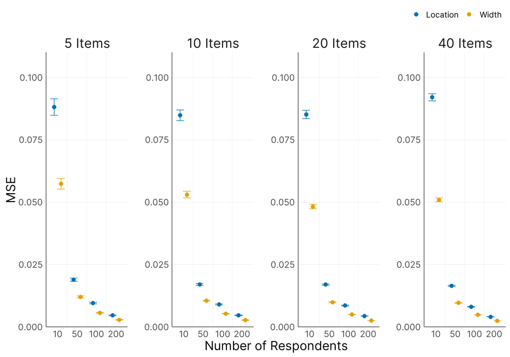

```r
plot_sim_mse_widloc <- sim_res_itm_long |>
  filter(pm == "mse") |>
  filter(summary == "mean") |>
  filter(measure %in% c("Trloc", "Trwid")) |>
  mutate(measure = case_when(
    measure == "Trloc" ~ "Location",
    measure == "Trwid" ~ "Width"
  )) |>
  mutate(n_items = paste0(n_items, " Items")) |>
  # order n_items correctly
  mutate(n_items = factor(n_items, levels = c("5 Items",
                                              "10 Items",
                                              "20 Items",
                                              "40 Items"))) |>
  ggplot(aes(x = n_respondents,
             y = mean,
             color = measure,
             group = measure)) +
  # add vertical line between different sample sizes
  geom_vline(colour = "#F3F4F5", xintercept = seq(1.5, 4, 1))+
  geom_point(position = position_dodge(0.7),
             size = 2.5) +
  geom_errorbar(aes(ymin = mean - 1*mcse,
                            ymax = mean + 1*mcse),
                        width = .8,
                 position = position_dodge(0.7),
                 show.legend = FALSE)+
  ggh4x::facet_wrap2(n_items ~ .,
                     axes = "all",
                     nrow = 1) +
  scale_y_continuous(limits = c(0, 0.11), expand = c(0,0)) +
  ggokabeito::scale_color_okabe_ito(order = c(5, 1))+
  labs(x = "Number of Respondents",
       y = "MSE",
       color = "") +
  theme_icm()+
  theme(legend.position = "top",
        text = element_text(size = 28))

# ggsave(here("plots","sim_main", "sim_mse_widloc.pdf"),
#        plot_sim_mse_widloc, width = 7, height = 3.75)

plot_sim_mse_widloc
```

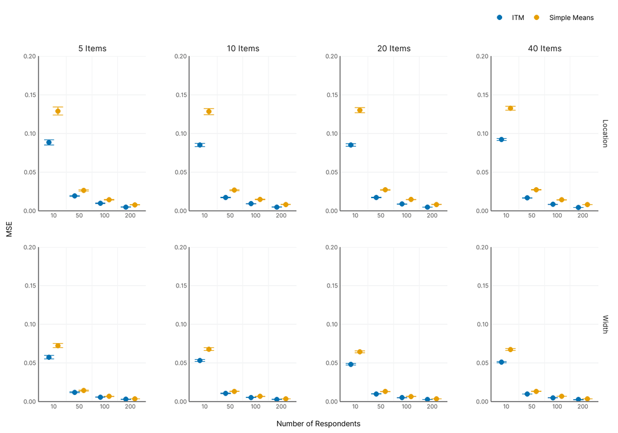

```r
plot_sim_mse_widloc_comb <- sim_res_itm_long |>
  filter(pm == "mse") |>
  filter(summary == "mean") |>
  filter(measure %in% c("Trloc", "Trwid", "simplemeanloc", "simplemeanwid")) |>
  # split based on model
  mutate(model = case_when(
    grepl("^Tr", measure) ~ "ITM",
    grepl("^simplemean", measure) ~ "Simple Means"
  ),
  measure = sub("^Tr|simplemean", "", measure)) |>
  mutate(measure = case_when(
    measure == "loc" ~ "Location",
    measure == "wid" ~ "Width")) |>
  mutate(n_items = paste0(n_items, " Items")) |>
  # order n_items correctly
  mutate(n_items = factor(n_items,
                          levels = c("5 Items", "10 Items", "20 Items", "40 Items"))) |>
  ggplot(aes(
    x = n_respondents,
    y = mean,
    color = model,
    group = model
  )) +
  # add vertical line between different sample sizes
  geom_vline(colour = "#F3F4F5", xintercept = seq(1.5, 4, 1)) +
  geom_point(position = position_dodge(0.7), size = 2.5) +
  geom_errorbar(
    aes(ymin = mean - 1 * mcse, ymax = mean + 1 * mcse),
    width = .8,
    position = position_dodge(0.7),
    show.legend = FALSE
  ) +
  ggh4x::facet_grid2(measure ~ n_items,
                     axes = "all") +
  scale_y_continuous(limits = c(0, 0.2), expand = c(0, 0)) +
  ggokabeito::scale_color_okabe_ito(order = c(5, 1)) +
  labs(x = "Number of Respondents", y = "MSE", color = "") +
  theme_icm() +
  # theme(legend.position = "top", text = element_text(size = 14))+
  # For manuscript plot:
  theme(legend.position = "top",
        text = element_text(size = 14),
        axis.text.x = element_text(size = 13.5, margin = margin(b = 10)),
        axis.text.y = element_text(size = 13.5, margin = margin(l = 10)),
        legend.text = element_text(size = 15.5))

plot_sim_mse_widloc_comb
```

```r
# ggsave(here("plots","sim_main", "sim_mse_widloc_comb.pdf"),
#        plot_sim_mse_widloc_comb, width = 11, height = 7)
```

### 3.2.3 Scatterplot of Location and Width Bias

Apply a function that retrieves location and width estimates to the results:

```r
locwid_bias <- prep_locwid(
  here(
    "sim_results",
    "sim_results_itm_2024-09-07_07-27-33",
    "full_sim_results_itm"
  )
)
# save the data
saveRDS(
  locwid_bias,
  here(
    "sim_results",
    "sim_results_itm_2024-09-07_07-27-33",
    "locwid_bias.rds"
  )
)
```

Or just read in the results:

```r
locwid_bias <- readRDS(  here(
    "sim_results",
    "sim_results_itm_2024-09-07_07-27-33",
    "locwid_bias.rds"
  ))
```

We standardize these values with the true variances from the simulation. We obtain these true values as shown in the `generate_itm_data_sim_study` function:

```r
link <- "ilr"
mean_benchmark <- simplex_to_bvn(c(.4, .2, .4), type = link)
sd_benchmark_loc <- simplex_to_bvn(c(.98, .01, .01), type = link)
sd_benchmark_wid <- simplex_to_bvn(c(.495, .01, .495), type = link)

# mean for Tr_loc
mu_Tr_loc <- mean_benchmark[1]
# mean for Tr_wid
mu_Tr_wid <- mean_benchmark[2]
# SD forTr_loc
sigma_Tr_loc <- sd_benchmark_loc[1] / 4
# SD Tr_wid
sigma_Tr_wid <- abs(sd_benchmark_wid[2] - mean_benchmark[2]) / 4

# Then standardize the values
locwid_bias <- locwid_bias |>
  dplyr::mutate(loc_bias_std = loc_bias / sigma_Tr_loc,
                wid_bias_std = wid_bias / sigma_Tr_wid)
```

Then create a scatterplot to investigate compensatory behavior, in other words, if the bias of the location is higher when the bias of the width is lower and vice versa. Overall, there does not seem to be strong evidence for compensatory behavior.

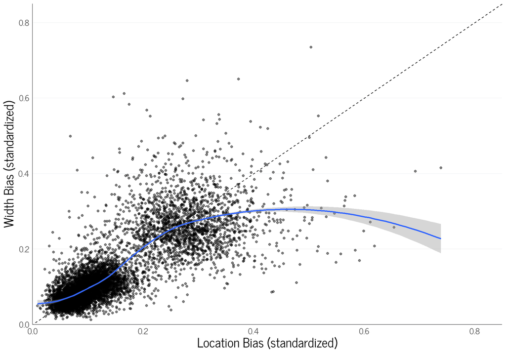

```r
# if fonts aren't working properly with ggExtra
# extrafont::font_import()

# # add google font
sysfonts::font_add_google("News Cycle", "news")
# use showtext
showtext::showtext_auto()
# windows()
# extrafont::font_import(pattern = "NewsCycle-Regular.ttf")
# extrafont::loadfonts()

scatter_tmp <- locwid_bias |>
  ggplot(aes(x = loc_bias_std, y = wid_bias_std)) +
  geom_point(alpha = 0.5) +
  geom_abline(intercept = 0, slope = 1, linetype = "dashed") +
  labs(x = "Location Bias (standardized)",
       y = "Width Bias (standardized)") +
  geom_smooth(method = "loess", se = TRUE) +
  scale_x_continuous(limits = c(0, .85), expand = c(0,0)) +
  scale_y_continuous(limits = c(0, .85), expand = c(0,0)) +
  # manually set theme here due to font conflicts
  ggplot2::theme_minimal(base_family = "news") +
  ggplot2::theme(
      # remove minor grid
      panel.grid.minor = ggplot2::element_blank(),
      # Title and Axis Texts
      plot.title = ggplot2::element_text(face = "plain",
                                         size = ggplot2::rel(1.2),
                                         hjust = 0.5),
      plot.subtitle = ggplot2::element_text(size = ggplot2::rel(1.1),
                                            hjust = 0.5),
      axis.text.x = ggplot2::element_text(face = "plain", size = ggplot2::rel(1.05)),
      axis.text.y = ggplot2::element_text(face = "plain", size = ggplot2::rel(1.05)),
      axis.title.x = ggplot2::element_text(face = "plain", size = ggplot2::rel(1.3)),
      axis.title.y = ggplot2::element_text(face = "plain", size = ggplot2::rel(1.3)),
      axis.line = element_line(colour = "#6d6d6e"),

      # Faceting
      strip.text = ggplot2::element_text(face = "plain",
                                         size = ggplot2::rel(1.1),
                                         hjust = 0.5),
      strip.text.x.top = ggplot2::element_text(face = "plain",
                                               size = ggplot2::rel(1.2),
                                               hjust = 0.5),
      # strip.text.y = element_blank(),
      strip.background = ggplot2::element_rect(fill = NA, color = NA),
      # Grid
      panel.grid = ggplot2::element_line(colour = "#F3F4F5"),
      # Legend
      legend.title = ggplot2::element_text(face = "plain"),
      legend.position = "top",
      legend.justification = 1,
      # Panel/Facets
      panel.spacing.x = ggplot2::unit(1.6, "lines"),
      panel.spacing.y = ggplot2::unit(1.6, "lines"),
      # Remove vertical grid lines
      panel.grid.major.x = ggplot2::element_blank())+
  theme(text = element_text(size = 28))

# show marginal distributions as histograms
# doesn't work with custom font
# scatter_locwid <- ggExtra::ggMarginal(scatter_tmp, type = "histogram", bins = 50)+
#   theme_minimal(base_family = "news")

# ggsave(here("plots","sim_main", "scatter_locwid.pdf"),
#        scatter_tmp, width = 7, height = 5)

scatter_tmp
```

### 3.2.4 Visualization of raw results

Instead of only showing aggregate performance measures, we can also visualize the raw repetition-wise performance measures to investigate the variability and potential skewness of the performance.

```r
raw_absbias <-
  prep_locwid(
    here(
      "sim_results",
      "sim_results_itm_2024-09-07_07-27-33",
      "full_sim_results_itm"
    ),
    simplemeans = TRUE
  )
saveRDS(
  raw_absbias,
  here(
    "sim_results",
    "sim_results_itm_2024-09-07_07-27-33",
    "raw_absbias.rds"
  )
)
```

```r
raw_absbias <- readRDS(
  here(
    "sim_results",
    "sim_results_itm_2024-09-07_07-27-33",
    "raw_absbias.rds"
  )
)
```

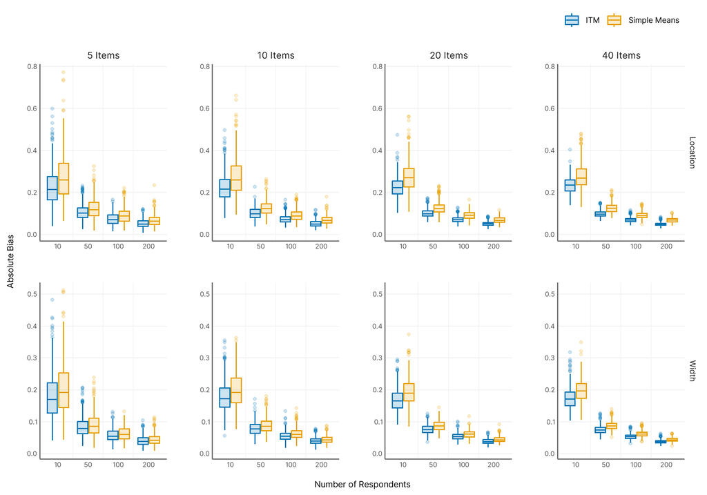

```r
# attach them to the condition-wise results
raw_ests_boxplot <- sim_res_itm |>
  mutate(iteration = row_number()) |>
  dplyr::select(n_respondents, n_items, iteration) |>
  right_join(raw_absbias, by = "iteration") |>
  pivot_longer(cols = c(loc_bias, wid_bias, smloc_bias, smwid_bias)) |>
  mutate(n_respondents = factor(n_respondents)) |>
  mutate(name = gsub("_bias", "", name)) |>
  mutate(name = case_match(name,
                           "loc" ~ "ITM Location",
                           "wid" ~ "ITM Width",
                           "smloc" ~ "Simplemeans Location",
                           "smwid" ~ "Simplemeans Width",
                           .default = name)) |>
  separate_wider_delim(name, delim = " ", names = c("model", "measure")) |>
  mutate(model = gsub("Simplemeans", "Simple Means", model)) |>
  mutate(n_items = paste0(n_items, " Items")) |>
  # order n_items correctly
  mutate(n_items = factor(n_items,
                          levels = c("5 Items", "10 Items", "20 Items", "40 Items"))) |>
  mutate(n_respondents = as_factor(n_respondents)) |>
    ggplot(aes(
    x = n_respondents,
    y = value,
    color = model,
    group = model,
    fill = model
  )) +
  # add vertical line between different sample sizes
  geom_vline(colour = "#F3F4F5", xintercept = seq(1.5, 4, 1)) +
  # ggdist::stat_halfeye(
  #   position = "dodge",
  #   scale = 5
  # ) +
  geom_boxplot(alpha = .2, lwd = 0.6, fatten = 0.9,
               inherit.aes = FALSE,
               aes(x = n_respondents,
                   y = value,
                   fill = model,
                   color = model))+
  # geom_point(
  #   size = 1,
  #   alpha = 0.15,
  #   position = ggplot2::position_dodge(width = .6)
  # )+
  # geom_jitter(size=0.4, alpha=0.2) +
  ggh4x::facet_grid2(measure ~ n_items,
                     axes = "all",
                     scales = "free_y") +
  # scale_y_continuous(limits = c(0, 1), expand = c(0, 0)) +
  ggokabeito::scale_color_okabe_ito(order = c(5, 1)) +
  ggokabeito::scale_fill_okabe_ito(order = c(5, 1)) +
  labs(x = "Number of Respondents",
       y = "Absolute Bias",
       color = "",
       fill = "") +
  theme_icm() +
  # theme(legend.position = "top", text = element_text(size = 18))+
  # For manuscript plot:
  theme(legend.position = "top",
        text = element_text(size = 14),
        axis.text.x = element_text(size = 13.5, margin = margin(b = 10)),
        axis.text.y = element_text(size = 13.5, margin = margin(l = 10)),
        legend.text = element_text(size = 15.5))

raw_ests_boxplot
```

```r
# ggsave(here("plots","sim_main", "raw_ests_boxplot.pdf"),
#        raw_ests_boxplot, width = 15, height = 7)
```

### 3.2.5 Summary Table

To show the numerical results of the main outcome measures, we create a summary table below.

```r
sim_res_itm |>
  dplyr::select(n_items, n_respondents,
         Tr_interval_mean_fn_abs_bias_mean, Tr_interval_mean_fn_abs_bias_mcse,
         Tr_interval_mean_fn_mse_mean, Tr_interval_mean_fn_mse_mcse,
         simplemean_interval_mean_fn_abs_bias_mcse, simplemean_interval_mean_fn_abs_bias_mean,
         simplemean_interval_mean_fn_mse_mean, simplemean_interval_mean_fn_mse_mcse) |>
  pivot_longer(cols = !c(n_items, n_respondents)) |>
  # split based on last underscore
  separate(name, into = c("name", "suffix"), sep = "_(?=[^_]+$)", remove = FALSE) |>
  pivot_wider(names_from = suffix, values_from = value) |>
  # again split based on last underscore
  separate(name, into = c("name", "pm"), sep = "_(?=[^_]+$)", remove = FALSE) |>
  # remove "mean_fn" from name
  mutate(name = str_remove(name, "_mean_fn_abs")) |>
  mutate(name = str_remove(name, "_mean_fn")) |>
  dplyr::rename(
    "Items" = "n_items",
    "Respondents" = "n_respondents",
    "Model" = "name",
    "Measure" = "pm",
    "Mean" = "mean",
    "MCSE" = "mcse"
  ) |>
  mutate(Model = case_when(
    Model == "Tr_interval" ~ "ITM",
    Model == "simplemean_interval" ~ "Simple Means"
  )) |>
  mutate(Measure = case_when(
    Measure == "bias" ~ "Bias",
    Measure == "mse" ~ "MSE"
  )) |>
  arrange(Items, Respondents) |>
  mutate(across(c(Mean, MCSE), ~round(., 4))) |>
  knitr::kable()
```

| Items | Respondents | Model | Measure | Mean | MCSE |
| --- | --- | --- | --- | --- | --- |
| 5 | 10 | ITM | Bias | 0.4094 | 0.0055 |
| 5 | 10 | ITM | MSE | 0.1455 | 0.0040 |
| 5 | 10 | Simple Means | Bias | 0.4782 | 0.0063 |
| 5 | 10 | Simple Means | MSE | 0.4782 | 0.0063 |
| 5 | 50 | ITM | Bias | 0.1906 | 0.0024 |
| 5 | 50 | ITM | MSE | 0.0308 | 0.0008 |
| 5 | 50 | Simple Means | Bias | 0.2155 | 0.0027 |
| 5 | 50 | Simple Means | MSE | 0.2155 | 0.0028 |
| 5 | 100 | ITM | Bias | 0.1320 | 0.0016 |
| 5 | 100 | ITM | MSE | 0.0151 | 0.0004 |
| 5 | 100 | Simple Means | Bias | 0.1539 | 0.0019 |
| 5 | 100 | Simple Means | MSE | 0.1539 | 0.0019 |
| 5 | 200 | ITM | Bias | 0.0928 | 0.0011 |
| 5 | 200 | ITM | MSE | 0.0073 | 0.0002 |
| 5 | 200 | Simple Means | Bias | 0.1106 | 0.0014 |
| 5 | 200 | Simple Means | MSE | 0.1106 | 0.0014 |
| 10 | 10 | ITM | Bias | 0.4033 | 0.0038 |
| 10 | 10 | ITM | MSE | 0.1378 | 0.0027 |
| 10 | 10 | Simple Means | Bias | 0.4712 | 0.0048 |
| 10 | 10 | Simple Means | MSE | 0.4712 | 0.0049 |
| 10 | 50 | ITM | Bias | 0.1802 | 0.0016 |
| 10 | 50 | ITM | MSE | 0.0275 | 0.0005 |
| 10 | 50 | Simple Means | Bias | 0.2133 | 0.0019 |
| 10 | 50 | Simple Means | MSE | 0.2133 | 0.0020 |
| 10 | 100 | ITM | Bias | 0.1276 | 0.0011 |
| 10 | 100 | ITM | MSE | 0.0141 | 0.0003 |
| 10 | 100 | Simple Means | Bias | 0.1540 | 0.0015 |
| 10 | 100 | Simple Means | MSE | 0.1540 | 0.0014 |
| 10 | 200 | ITM | Bias | 0.0918 | 0.0009 |
| 10 | 200 | ITM | MSE | 0.0073 | 0.0001 |
| 10 | 200 | Simple Means | Bias | 0.1123 | 0.0010 |
| 10 | 200 | Simple Means | MSE | 0.1123 | 0.0010 |
| 20 | 10 | ITM | Bias | 0.3946 | 0.0028 |
| 20 | 10 | ITM | MSE | 0.1333 | 0.0019 |
| 20 | 10 | Simple Means | Bias | 0.4697 | 0.0037 |
| 20 | 10 | Simple Means | MSE | 0.4697 | 0.0037 |
| 20 | 50 | ITM | Bias | 0.1769 | 0.0012 |
| 20 | 50 | ITM | MSE | 0.0267 | 0.0004 |
| 20 | 50 | Simple Means | Bias | 0.2134 | 0.0015 |
| 20 | 50 | Simple Means | MSE | 0.2134 | 0.0015 |
| 20 | 100 | ITM | Bias | 0.1250 | 0.0008 |
| 20 | 100 | ITM | MSE | 0.0134 | 0.0002 |
| 20 | 100 | Simple Means | Bias | 0.1530 | 0.0011 |
| 20 | 100 | Simple Means | MSE | 0.1530 | 0.0010 |
| 20 | 200 | ITM | Bias | 0.0893 | 0.0006 |
| 20 | 200 | ITM | MSE | 0.0068 | 0.0001 |
| 20 | 200 | Simple Means | Bias | 0.1134 | 0.0008 |
| 20 | 200 | Simple Means | MSE | 0.1134 | 0.0008 |
| 40 | 10 | ITM | Bias | 0.4095 | 0.0024 |
| 40 | 10 | ITM | MSE | 0.1429 | 0.0017 |
| 40 | 10 | Simple Means | Bias | 0.4763 | 0.0032 |
| 40 | 10 | Simple Means | MSE | 0.4763 | 0.0031 |
| 40 | 50 | ITM | Bias | 0.1742 | 0.0009 |
| 40 | 50 | ITM | MSE | 0.0260 | 0.0003 |
| 40 | 50 | Simple Means | Bias | 0.2135 | 0.0011 |
| 40 | 50 | Simple Means | MSE | 0.2135 | 0.0012 |
| 40 | 100 | ITM | Bias | 0.1227 | 0.0006 |
| 40 | 100 | ITM | MSE | 0.0129 | 0.0001 |
| 40 | 100 | Simple Means | Bias | 0.1534 | 0.0008 |
| 40 | 100 | Simple Means | MSE | 0.1534 | 0.0008 |
| 40 | 200 | ITM | Bias | 0.0863 | 0.0004 |
| 40 | 200 | ITM | MSE | 0.0064 | 0.0001 |
| 40 | 200 | Simple Means | Bias | 0.1119 | 0.0006 |
| 40 | 200 | Simple Means | MSE | 0.1119 | 0.0006 |

**R version 4.5.0 (2025-04-11 ucrt)**

**Platform:** x86_64-w64-mingw32/x64

**locale:** *LC_COLLATE=German_Germany.utf8*, *LC_CTYPE=German_Germany.utf8*, *LC_MONETARY=German_Germany.utf8*, *LC_NUMERIC=C* and *LC_TIME=German_Germany.utf8*

**attached base packages:** *stats*, *graphics*, *grDevices*, *utils*, *datasets*, *methods* and *base*

**other attached packages:** *extraDistr(v.1.10.0)*, *cmdstanr(v.0.8.0)*, *pander(v.0.6.6)*, *ggdist(v.3.3.3)*, *showtext(v.0.9-7)*, *showtextdb(v.3.0)*, *sysfonts(v.0.8.9)*, *ggExtra(v.0.10.1)*, *ggokabeito(v.0.1.0)*, *ggh4x(v.0.3.1.9000)*, *psych(v.2.5.6)*, *here(v.1.0.1)*, *SimDesign(v.2.19.2)*, *lubridate(v.1.9.4)*, *forcats(v.1.0.0)*, *stringr(v.1.5.1)*, *dplyr(v.1.1.4)*, *purrr(v.1.0.4)*, *readr(v.2.1.5)*, *tidyr(v.1.3.1)*, *tibble(v.3.3.0)*, *ggplot2(v.3.5.2)*, *tidyverse(v.2.0.0)* and *pacman(v.0.5.1)*

**loaded via a namespace (and not attached):** *tidyselect(v.1.2.1)*, *farver(v.2.1.2)*, *R.utils(v.2.13.0)*, *fastmap(v.1.2.0)*, *tensorA(v.0.36.2.1)*, *promises(v.1.3.3)*, *digest(v.0.6.37)*, *timechange(v.0.3.0)*, *mime(v.0.13)*, *lifecycle(v.1.0.4)*, *processx(v.3.8.6)*, *magrittr(v.2.0.3)*, *posterior(v.1.6.1)*, *compiler(v.4.5.0)*, *rlang(v.1.1.6)*, *tools(v.4.5.0)*, *yaml(v.2.3.10)*, *knitr(v.1.50)*, *labeling(v.0.4.3)*, *htmlwidgets(v.1.6.4)*, *curl(v.6.4.0)*, *mnormt(v.2.1.1)*, *RColorBrewer(v.1.1-3)*, *abind(v.1.4-8)*, *miniUI(v.0.1.2)*, *withr(v.3.0.2)*, *R.oo(v.1.27.1)*, *grid(v.4.5.0)*, *xtable(v.1.8-4)*, *future(v.1.58.0)*, *progressr(v.0.15.1)*, *globals(v.0.18.0)*, *scales(v.1.4.0)*, *cli(v.3.6.5)*, *rmarkdown(v.2.29)*, *ragg(v.1.4.0)*, *generics(v.0.1.4)*, *rstudioapi(v.0.17.1)*, *future.apply(v.1.20.0)*, *tzdb(v.0.5.0)*, *sessioninfo(v.1.2.3)*, *pbapply(v.1.7-2)*, *splines(v.4.5.0)*, *audio(v.0.1-11)*, *parallel(v.4.5.0)*, *beepr(v.2.0)*, *vctrs(v.0.6.5)*, *Matrix(v.1.7-3)*, *jsonlite(v.2.0.0)*, *hms(v.1.1.3)*, *listenv(v.0.9.1)*, *systemfonts(v.1.2.3)*, *testthat(v.3.2.3)*, *glue(v.1.8.0)*, *parallelly(v.1.45.0)*, *ps(v.1.9.1)*, *codetools(v.0.2-20)*, *distributional(v.0.5.0)*, *stringi(v.1.8.7)*, *gtable(v.0.3.6)*, *later(v.1.4.2)*, *pillar(v.1.11.0)*, *htmltools(v.0.5.8.1)*, *brio(v.1.1.5)*, *R6(v.2.6.1)*, *textshaping(v.1.0.1)*, *rprojroot(v.2.0.4)*, *evaluate(v.1.0.4)*, *shiny(v.1.11.0)*, *lattice(v.0.22-7)*, *backports(v.1.5.0)*, *R.methodsS3(v.1.8.2)*, *httpuv(v.1.6.16)*, *Rcpp(v.1.0.14)*, *nlme(v.3.1-168)*, *checkmate(v.2.3.2)*, *mgcv(v.1.9-3)*, *xfun(v.0.52)* and *pkgconfig(v.2.0.3)*